# 05 Financial Risk Scoring and Dashboard Preparation

This notebook converts the final supervised Random Forest model into a transaction-level risk scoring output. The Random Forest model is used as the primary decision model because it achieved the strongest supervised performance. The Autoencoder is not used as a hard decision rule because the incremental value analysis showed that it did not capture fraud cases missed by Random Forest and would introduce many extra false positives. Autoencoder outputs may be retained only as monitoring fields.

This is a post-transaction fraud detection and risk monitoring system because it uses transaction outcome and balance-related fields. The final risk score should be interpreted as a model-based fraud risk score, not necessarily a perfectly calibrated probability.

## 1. Import Libraries and Project Modules

```python
import json
import sys
from pathlib import Path

import joblib
import matplotlib.pyplot as plt
import numpy as np
import pandas as pd
from sklearn.model_selection import train_test_split

PROJECT_ROOT = Path("..").resolve()
if str(PROJECT_ROOT) not in sys.path:
    sys.path.insert(0, str(PROJECT_ROOT))

from src.preprocessing import (
    create_engineered_features,
    load_paysim_data,
    prepare_features_and_target,
)
from src.risk_scoring import (
    add_autoencoder_monitoring_columns,
    create_dashboard_summary,
    create_risk_scoring_dataframe,
    evaluate_threshold_decisions,
    load_json,
    save_risk_scoring_outputs,
    select_threshold_by_business_policy,
    summarize_recommended_actions,
    summarize_risk_bands,
)

RANDOM_STATE = 42
```

## 2. Define Paths

The notebook loads the local PaySim CSV from the project data directory.

```python
DATA_PATH = Path("../data/raw/financial/paysim.csv")
FALLBACK_DATA_PATH = Path("../data/raw/PS_20174392719_1491204439457_log.csv")

FINAL_SUPERVISED_MODEL_PATH = Path("../models/ml/final_supervised_model.pkl")

AUTOENCODER_TEST_ERRORS_PATH = Path("../reports/autoencoder_test_reconstruction_errors.csv")
AUTOENCODER_THRESHOLD_PATH = Path("../models/autoencoder/autoencoder_threshold.json")

REPORTS_DIR = Path("../reports")

if not FINAL_SUPERVISED_MODEL_PATH.exists():
    raise FileNotFoundError(
        "Final supervised model was not found at "
        f"{FINAL_SUPERVISED_MODEL_PATH.resolve()}. "
        "Please run the supervised model selection workflow first."
    )

if not DATA_PATH.exists():
    if FALLBACK_DATA_PATH.exists():
        print(f"Primary DATA_PATH not found. Using fallback file: {FALLBACK_DATA_PATH.resolve()}")
        DATA_PATH = FALLBACK_DATA_PATH
    else:
        raise FileNotFoundError(
            "No PaySim raw data file was found at the primary path or fallback path."
        )

print(f"Data path: {DATA_PATH.resolve()}")
print(f"Final supervised model path: {FINAL_SUPERVISED_MODEL_PATH.resolve()}")
print(f"Reports directory: {REPORTS_DIR.resolve()}")
```

```
Data path: D:\cs s1 26\基于深度学习的交易欺诈检测与智能风控系统\transaction-fraud-detection-system\data\raw\financial\paysim.csv
Final supervised model path: D:\cs s1 26\基于深度学习的交易欺诈检测与智能风控系统\transaction-fraud-detection-system\models\ml\final_supervised_model.pkl
Reports directory: D:\cs s1 26\基于深度学习的交易欺诈检测与智能风控系统\transaction-fraud-detection-system\reports
```

## 3. Load and Prepare Data

```python
raw_df = load_paysim_data(DATA_PATH)
data_df = create_engineered_features(raw_df)
X, y = prepare_features_and_target(data_df)

print(f"Dataset shape after feature engineering: {data_df.shape}")
print(f"X shape: {X.shape}")
print("Target distribution:")
print(y.value_counts().sort_index())
print(f"Fraud rate: {y.mean():.6f}")
```

```
Dataset shape after feature engineering: (6362620, 20)
X shape: (6362620, 16)
Target distribution:
isFraud
0    6354407
1       8213
Name: count, dtype: int64
Fraud rate: 0.001291
```

## 4. Recreate Train / Validation / Test Split

The split mirrors the earlier modeling notebooks: 60% train, 20% validation, and 20% test. Validation is used for final business threshold selection. Test is used only for final holdout evaluation.

```python
X_train_val, X_test, y_train_val, y_test = train_test_split(
    X,
    y,
    test_size=0.20,
    random_state=RANDOM_STATE,
    stratify=y,
)

X_train_full, X_val, y_train_full, y_val = train_test_split(
    X_train_val,
    y_train_val,
    test_size=0.25,
    random_state=RANDOM_STATE,
    stratify=y_train_val,
)

print(f"Train shape: {X_train_full.shape}, fraud count: {int(y_train_full.sum())}")
print(f"Validation shape: {X_val.shape}, fraud count: {int(y_val.sum())}")
print(f"Test shape: {X_test.shape}, fraud count: {int(y_test.sum())}")
```

```
Train shape: (3817572, 16), fraud count: 4928
Validation shape: (1272524, 16), fraud count: 1642
Test shape: (1272524, 16), fraud count: 1643
```

## 5. Load Final Random Forest Model

The final supervised model is loaded from disk and is not refit in this notebook.

```python
final_supervised_model = joblib.load(FINAL_SUPERVISED_MODEL_PATH)

if not hasattr(final_supervised_model, "predict_proba"):
    raise AttributeError(
        "The final supervised model does not expose predict_proba. "
        "Risk scoring requires probability-like fraud scores."
    )

val_fraud_proba = final_supervised_model.predict_proba(X_val)[:, 1]
test_fraud_proba = final_supervised_model.predict_proba(X_test)[:, 1]

print(f"Validation fraud score range: {val_fraud_proba.min():.6f} to {val_fraud_proba.max():.6f}")
print(f"Test fraud score range: {test_fraud_proba.min():.6f} to {test_fraud_proba.max():.6f}")
```

[output not shown]

```
Validation fraud score range: 0.000000 to 1.000000
Test fraud score range: 0.000000 to 1.000000
```

## 6. Select Final Business Threshold on Validation Set

The threshold is selected on the validation set only. The policy prioritizes recall while keeping the review queue under a maximum review budget and maintaining high precision. The test set is not used for threshold selection.

```python
MAX_REVIEW_RATE = 0.005
MIN_PRECISION = 0.90

selected_threshold, threshold_results_df, threshold_metadata = select_threshold_by_business_policy(
    y_true=y_val,
    y_scores=val_fraud_proba,
    max_review_rate=MAX_REVIEW_RATE,
    min_precision=MIN_PRECISION,
    fallback_threshold=0.5,
)

print(json.dumps(threshold_metadata, indent=2))

top_threshold_candidates = threshold_results_df.sort_values(
    by=["recall", "precision", "f1"],
    ascending=False,
).head(10)

top_threshold_candidates
```

```
{
  "selected_threshold": 0.5526582914572864,
  "max_review_rate": 0.005,
  "min_precision": 0.9,
  "selection_policy": "maximize_recall_under_review_rate_and_precision_constraints",
  "fallback_used": false,
  "selected_precision": 0.9987834549878345,
  "selected_recall": 1.0,
  "selected_f1": 0.9993913572732805,
  "selected_predicted_positive_rate": 0.0012919206238939304
}
```

|  | model | threshold | accuracy | precision | recall | f1 | roc_auc | pr_auc | tn | fp | fn | tp | predicted_positive_count | predicted_positive_rate |
| --- | --- | --- | --- | --- | --- | --- | --- | --- | --- | --- | --- | --- | --- | --- |
| 118 | Random Forest | 0.552658 | 0.999998 | 0.998783 | 1.0 | 0.999391 | 1.0 | 0.999999 | 1270880 | 2 | 0 | 1642 | 1644 | 0.001292 |
| 119 | Random Forest | 0.557673 | 0.999998 | 0.998783 | 1.0 | 0.999391 | 1.0 | 0.999999 | 1270880 | 2 | 0 | 1642 | 1644 | 0.001292 |
| 120 | Random Forest | 0.562688 | 0.999998 | 0.998783 | 1.0 | 0.999391 | 1.0 | 0.999999 | 1270880 | 2 | 0 | 1642 | 1644 | 0.001292 |
| 121 | Random Forest | 0.567704 | 0.999998 | 0.998783 | 1.0 | 0.999391 | 1.0 | 0.999999 | 1270880 | 2 | 0 | 1642 | 1644 | 0.001292 |
| 122 | Random Forest | 0.572719 | 0.999998 | 0.998783 | 1.0 | 0.999391 | 1.0 | 0.999999 | 1270880 | 2 | 0 | 1642 | 1644 | 0.001292 |
| 123 | Random Forest | 0.577734 | 0.999998 | 0.998783 | 1.0 | 0.999391 | 1.0 | 0.999999 | 1270880 | 2 | 0 | 1642 | 1644 | 0.001292 |
| 124 | Random Forest | 0.582749 | 0.999998 | 0.998783 | 1.0 | 0.999391 | 1.0 | 0.999999 | 1270880 | 2 | 0 | 1642 | 1644 | 0.001292 |
| 125 | Random Forest | 0.587764 | 0.999998 | 0.998783 | 1.0 | 0.999391 | 1.0 | 0.999999 | 1270880 | 2 | 0 | 1642 | 1644 | 0.001292 |
| 126 | Random Forest | 0.592779 | 0.999998 | 0.998783 | 1.0 | 0.999391 | 1.0 | 0.999999 | 1270880 | 2 | 0 | 1642 | 1644 | 0.001292 |
| 127 | Random Forest | 0.597794 | 0.999998 | 0.998783 | 1.0 | 0.999391 | 1.0 | 0.999999 | 1270880 | 2 | 0 | 1642 | 1644 | 0.001292 |

## 7. Evaluate Selected Threshold on Validation and Test

Validation is used for threshold selection. Test is used only for final holdout evaluation of the selected decision rule.

```python
validation_final_metrics_df = evaluate_threshold_decisions(
    y_true=y_val,
    y_scores=val_fraud_proba,
    threshold=selected_threshold,
    model_name="Random Forest (Validation Selected Threshold)",
)

test_final_metrics_df = evaluate_threshold_decisions(
    y_true=y_test,
    y_scores=test_fraud_proba,
    threshold=selected_threshold,
    model_name="Random Forest (Test Selected Threshold)",
)

display(validation_final_metrics_df)
display(test_final_metrics_df)
```

|  | model | threshold | accuracy | precision | recall | f1 | roc_auc | pr_auc | tn | fp | fn | tp | predicted_positive_count | predicted_positive_rate |
| --- | --- | --- | --- | --- | --- | --- | --- | --- | --- | --- | --- | --- | --- | --- |
| 0 | Random Forest (Validation Selected Threshold) | 0.552658 | 0.999998 | 0.998783 | 1.0 | 0.999391 | 1.0 | 0.999999 | 1270880 | 2 | 0 | 1642 | 1644 | 0.001292 |

|  | model | threshold | accuracy | precision | recall | f1 | roc_auc | pr_auc | tn | fp | fn | tp | predicted_positive_count | predicted_positive_rate |
| --- | --- | --- | --- | --- | --- | --- | --- | --- | --- | --- | --- | --- | --- | --- |
| 0 | Random Forest (Test Selected Threshold) | 0.552658 | 0.999996 | 0.99939 | 0.997565 | 0.998477 | 0.999978 | 0.998844 | 1270880 | 1 | 4 | 1639 | 1640 | 0.001289 |

## 8. Compare with Default 0.5 Threshold

This comparison shows whether the business threshold changes review volume, recall, precision, false positives, and false negatives compared with the default model decision threshold.

```python
default_test_metrics_df = evaluate_threshold_decisions(
    y_true=y_test,
    y_scores=test_fraud_proba,
    threshold=0.5,
    model_name="Random Forest (Test Default 0.5 Threshold)",
)

threshold_comparison_df = pd.concat(
    [test_final_metrics_df, default_test_metrics_df],
    ignore_index=True,
)

threshold_comparison_df[
    [
        "model",
        "threshold",
        "precision",
        "recall",
        "f1",
        "fp",
        "fn",
        "tp",
        "predicted_positive_count",
        "predicted_positive_rate",
    ]
]
```

|  | model | threshold | precision | recall | f1 | fp | fn | tp | predicted_positive_count | predicted_positive_rate |
| --- | --- | --- | --- | --- | --- | --- | --- | --- | --- | --- |
| 0 | Random Forest (Test Selected Threshold) | 0.552658 | 0.999390 | 0.997565 | 0.998477 | 1 | 4 | 1639 | 1640 | 0.001289 |
| 1 | Random Forest (Test Default 0.5 Threshold) | 0.500000 | 0.996353 | 0.997565 | 0.996959 | 6 | 4 | 1639 | 1645 | 0.001293 |

## 9. Create Transaction-Level Risk Scoring DataFrame

```python
risk_df = create_risk_scoring_dataframe(
    X=X_test,
    y_true=y_test,
    fraud_scores=test_fraud_proba,
    selected_threshold=selected_threshold,
)

display(risk_df.head())
risk_df.sort_values("rf_fraud_probability", ascending=False).head(20)
```

|  | original_index | isFraud | rf_fraud_probability | rf_risk_score_0_100 | final_review_flag | risk_band | recommended_action | type | amount | oldbalanceOrg | ... | oldbalanceDest | newbalanceDest | log_amount | orig_balance_change | dest_balance_change | orig_balance_error | dest_balance_error | amount_to_oldbalanceOrg_ratio_clipped | is_orig_balance_drained | is_high_risk_type |
| --- | --- | --- | --- | --- | --- | --- | --- | --- | --- | --- | --- | --- | --- | --- | --- | --- | --- | --- | --- | --- | --- |
| 0 | 4051353 | 0 | 0.000000 | 0.000000 | False | Low | No action | TRANSFER | 890577.21 | 218.00 | ... | 0.00 | 890577.21 | 13.699626 | 218.00 | 890577.21 | -890359.21 | 0.000000e+00 | 100.000000 | 1 | 1 |
| 1 | 5746321 | 0 | 0.000000 | 0.000000 | False | Low | No action | CASH_IN | 97734.24 | 2096258.84 | ... | 320136.00 | 222401.76 | 11.490017 | -97734.24 | -97734.24 | -195468.48 | -1.954685e+05 | 0.046623 | 0 | 0 |
| 2 | 6361797 | 0 | 0.000000 | 0.000000 | False | Low | No action | PAYMENT | 5907.41 | 315.00 | ... | 0.00 | 0.00 | 8.684132 | 315.00 | 0.00 | -5592.41 | -5.907410e+03 | 18.694335 | 1 | 0 |
| 3 | 2247309 | 0 | 0.000019 | 0.001883 | False | Low | No action | CASH_OUT | 187696.30 | 11057.00 | ... | 1798095.21 | 1985791.51 | 12.142586 | 11057.00 | 187696.30 | -176639.30 | 5.820766e-11 | 16.973802 | 1 | 1 |
| 4 | 4692207 | 0 | 0.000165 | 0.016470 | False | Low | No action | CASH_OUT | 82646.52 | 0.00 | ... | 1047805.87 | 1130452.39 | 11.322340 | 0.00 | 82646.52 | -82646.52 | -1.018634e-10 | 100.000000 | 1 | 1 |

5 rows × 21 columns

|  | original_index | isFraud | rf_fraud_probability | rf_risk_score_0_100 | final_review_flag | risk_band | recommended_action | type | amount | oldbalanceOrg | ... | oldbalanceDest | newbalanceDest | log_amount | orig_balance_change | dest_balance_change | orig_balance_error | dest_balance_error | amount_to_oldbalanceOrg_ratio_clipped | is_orig_balance_drained | is_high_risk_type |
| --- | --- | --- | --- | --- | --- | --- | --- | --- | --- | --- | --- | --- | --- | --- | --- | --- | --- | --- | --- | --- | --- |
| 999546 | 4142544 | 1 | 1.0 | 99.999994 | True | Critical | Manual review | TRANSFER | 786480.78 | 786480.78 | ... | 0.00 | 0.00 | 13.575325 | 786480.78 | 0.00 | 0.0 | -7.864808e+05 | 0.999999 | 1 | 1 |
| 1215449 | 6009722 | 1 | 1.0 | 99.999994 | True | Critical | Manual review | CASH_OUT | 3085.45 | 3085.45 | ... | 45631.02 | 48716.47 | 8.034777 | 3085.45 | 3085.45 | 0.0 | 4.547474e-12 | 0.999676 | 1 | 1 |
| 1270811 | 5725126 | 1 | 1.0 | 99.999994 | True | Critical | Manual review | TRANSFER | 3580542.06 | 3580542.06 | ... | 0.00 | 0.00 | 15.091025 | 3580542.06 | 0.00 | 0.0 | -3.580542e+06 | 1.000000 | 1 | 1 |
| 258998 | 4784216 | 1 | 1.0 | 99.999994 | True | Critical | Manual review | TRANSFER | 786573.00 | 786573.00 | ... | 0.00 | 0.00 | 13.575442 | 786573.00 | 0.00 | 0.0 | -7.865730e+05 | 0.999999 | 1 | 1 |
| 990275 | 4243262 | 1 | 1.0 | 99.999994 | True | Critical | Manual review | TRANSFER | 850530.59 | 850530.59 | ... | 0.00 | 0.00 | 13.653617 | 850530.59 | 0.00 | 0.0 | -8.505306e+05 | 0.999999 | 1 | 1 |
| 258630 | 2065130 | 1 | 1.0 | 99.999994 | True | Critical | Manual review | TRANSFER | 955505.54 | 955505.54 | ... | 0.00 | 0.00 | 13.769997 | 955505.54 | 0.00 | 0.0 | -9.555055e+05 | 0.999999 | 1 | 1 |
| 35766 | 1511340 | 1 | 1.0 | 99.999994 | True | Critical | Manual review | TRANSFER | 7188425.25 | 7188425.25 | ... | 0.00 | 0.00 | 15.787983 | 7188425.25 | 0.00 | 0.0 | -7.188425e+06 | 1.000000 | 1 | 1 |
| 279622 | 1059598 | 1 | 1.0 | 99.999994 | True | Critical | Manual review | TRANSFER | 1299860.86 | 1299860.86 | ... | 0.00 | 0.00 | 14.077769 | 1299860.86 | 0.00 | 0.0 | -1.299861e+06 | 0.999999 | 1 | 1 |
| 233706 | 1070156 | 1 | 1.0 | 99.999994 | True | Critical | Manual review | TRANSFER | 1848199.45 | 1848199.45 | ... | 0.00 | 0.00 | 14.429723 | 1848199.45 | 0.00 | 0.0 | -1.848199e+06 | 0.999999 | 1 | 1 |
| 1209244 | 1059506 | 1 | 1.0 | 99.999994 | True | Critical | Manual review | TRANSFER | 1515291.19 | 1515291.19 | ... | 0.00 | 0.00 | 14.231119 | 1515291.19 | 0.00 | 0.0 | -1.515291e+06 | 0.999999 | 1 | 1 |
| 1209482 | 3610967 | 1 | 1.0 | 99.999994 | True | Critical | Manual review | TRANSFER | 1070857.97 | 1070857.97 | ... | 0.00 | 0.00 | 13.883972 | 1070857.97 | 0.00 | 0.0 | -1.070858e+06 | 0.999999 | 1 | 1 |
| 649669 | 2453377 | 1 | 1.0 | 99.999994 | True | Critical | Manual review | TRANSFER | 2913787.08 | 2913787.08 | ... | 0.00 | 0.00 | 14.884965 | 2913787.08 | 0.00 | 0.0 | -2.913787e+06 | 1.000000 | 1 | 1 |
| 1019024 | 4387978 | 1 | 1.0 | 99.999994 | True | Critical | Manual review | TRANSFER | 5818863.13 | 5818863.13 | ... | 0.00 | 0.00 | 15.576616 | 5818863.13 | 0.00 | 0.0 | -5.818863e+06 | 1.000000 | 1 | 1 |
| 625072 | 3681230 | 1 | 1.0 | 99.999994 | True | Critical | Manual review | TRANSFER | 1567591.24 | 1567591.24 | ... | 0.00 | 0.00 | 14.265051 | 1567591.24 | 0.00 | 0.0 | -1.567591e+06 | 0.999999 | 1 | 1 |
| 257995 | 5810286 | 1 | 1.0 | 99.999994 | True | Critical | Manual review | TRANSFER | 1672570.76 | 1672570.76 | ... | 0.00 | 0.00 | 14.329873 | 1672570.76 | 0.00 | 0.0 | -1.672571e+06 | 0.999999 | 1 | 1 |
| 981062 | 1030641 | 1 | 1.0 | 99.999994 | True | Critical | Manual review | TRANSFER | 972920.87 | 972920.87 | ... | 0.00 | 0.00 | 13.788059 | 972920.87 | 0.00 | 0.0 | -9.729209e+05 | 0.999999 | 1 | 1 |
| 342443 | 1932025 | 1 | 1.0 | 99.999994 | True | Critical | Manual review | TRANSFER | 2612915.20 | 2612915.20 | ... | 0.00 | 0.00 | 14.775977 | 2612915.20 | 0.00 | 0.0 | -2.612915e+06 | 1.000000 | 1 | 1 |
| 349448 | 3869815 | 1 | 1.0 | 99.999994 | True | Critical | Manual review | TRANSFER | 924912.26 | 924912.26 | ... | 0.00 | 0.00 | 13.737455 | 924912.26 | 0.00 | 0.0 | -9.249123e+05 | 0.999999 | 1 | 1 |
| 133389 | 3137120 | 1 | 1.0 | 99.999994 | True | Critical | Manual review | TRANSFER | 1418198.25 | 1418198.25 | ... | 0.00 | 0.00 | 14.164898 | 1418198.25 | 0.00 | 0.0 | -1.418198e+06 | 0.999999 | 1 | 1 |
| 449440 | 5555664 | 1 | 1.0 | 99.999994 | True | Critical | Manual review | TRANSFER | 4731371.88 | 4731371.88 | ... | 0.00 | 0.00 | 15.369726 | 4731371.88 | 0.00 | 0.0 | -4.731372e+06 | 1.000000 | 1 | 1 |

20 rows × 21 columns

## 10. Add Optional Autoencoder Monitoring Fields

Autoencoder is included only as a monitoring field. It is not used as a hard rule because notebook 07 showed it did not add incremental fraud-capture value beyond Random Forest.

```python
ae_monitoring_added = False

if AUTOENCODER_TEST_ERRORS_PATH.exists():
    ae_errors_df = pd.read_csv(AUTOENCODER_TEST_ERRORS_PATH)
    error_column_candidates = [
        "reconstruction_error",
        "anomaly_score",
        "ae_reconstruction_error",
    ]
    ae_error_column = next(
        (column for column in error_column_candidates if column in ae_errors_df.columns),
        None,
    )

    if ae_error_column is None:
        print(
            "Warning: Autoencoder test errors file exists but no reconstruction "
            "error column was found. Skipping AE monitoring fields."
        )
    elif len(ae_errors_df) != len(risk_df):
        print(
            "Warning: Autoencoder test error length does not match risk_df. "
            f"AE rows: {len(ae_errors_df)}, risk rows: {len(risk_df)}. "
            "Skipping AE monitoring fields."
        )
    else:
        ae_threshold = None
        if AUTOENCODER_THRESHOLD_PATH.exists():
            ae_threshold_metadata = load_json(AUTOENCODER_THRESHOLD_PATH)
            ae_threshold = ae_threshold_metadata.get("threshold")
        else:
            print("Warning: Autoencoder threshold file not found. Flag will be skipped.")

        risk_df = add_autoencoder_monitoring_columns(
            risk_df=risk_df,
            ae_reconstruction_error=ae_errors_df[ae_error_column].to_numpy(),
            ae_threshold=ae_threshold,
        )
        ae_monitoring_added = "ae_reconstruction_error" in risk_df.columns
        print("Autoencoder monitoring fields added successfully.")
else:
    print(
        "Warning: Autoencoder test reconstruction errors file not found. "
        "Skipping AE monitoring fields."
    )

print(f"AE monitoring added: {ae_monitoring_added}")
risk_df.head()
```

```
Autoencoder monitoring fields added successfully.
AE monitoring added: True
```

|  | original_index | isFraud | rf_fraud_probability | rf_risk_score_0_100 | final_review_flag | risk_band | recommended_action | type | amount | oldbalanceOrg | ... | log_amount | orig_balance_change | dest_balance_change | orig_balance_error | dest_balance_error | amount_to_oldbalanceOrg_ratio_clipped | is_orig_balance_drained | is_high_risk_type | ae_reconstruction_error | ae_monitoring_flag |
| --- | --- | --- | --- | --- | --- | --- | --- | --- | --- | --- | --- | --- | --- | --- | --- | --- | --- | --- | --- | --- | --- |
| 0 | 4051353 | 0 | 0.000000 | 0.000000 | False | Low | No action | TRANSFER | 890577.21 | 218.00 | ... | 13.699626 | 218.00 | 890577.21 | -890359.21 | 0.000000e+00 | 100.000000 | 1 | 1 | 0.038276 | False |
| 1 | 5746321 | 0 | 0.000000 | 0.000000 | False | Low | No action | CASH_IN | 97734.24 | 2096258.84 | ... | 11.490017 | -97734.24 | -97734.24 | -195468.48 | -1.954685e+05 | 0.046623 | 0 | 0 | 0.012702 | False |
| 2 | 6361797 | 0 | 0.000000 | 0.000000 | False | Low | No action | PAYMENT | 5907.41 | 315.00 | ... | 8.684132 | 315.00 | 0.00 | -5592.41 | -5.907410e+03 | 18.694335 | 1 | 0 | 0.070772 | False |
| 3 | 2247309 | 0 | 0.000019 | 0.001883 | False | Low | No action | CASH_OUT | 187696.30 | 11057.00 | ... | 12.142586 | 11057.00 | 187696.30 | -176639.30 | 5.820766e-11 | 16.973802 | 1 | 1 | 0.009151 | False |
| 4 | 4692207 | 0 | 0.000165 | 0.016470 | False | Low | No action | CASH_OUT | 82646.52 | 0.00 | ... | 11.322340 | 0.00 | 82646.52 | -82646.52 | -1.018634e-10 | 100.000000 | 1 | 1 | 0.003290 | False |

5 rows × 23 columns

## 11. Create Risk Band and Action Summaries

```python
risk_band_summary_df = summarize_risk_bands(risk_df)
action_summary_df = summarize_recommended_actions(risk_df)

display(risk_band_summary_df)
display(action_summary_df)
```

|  | risk_band | transaction_count | transaction_rate | fraud_count | fraud_rate | review_count | review_rate | avg_rf_fraud_probability | max_rf_fraud_probability |
| --- | --- | --- | --- | --- | --- | --- | --- | --- | --- |
| 0 | Critical | 1639 | 0.001288 | 1639 | 1.000000e+00 | 1639 | 1.000000 | 0.998989 | 1.000000 |
| 1 | Elevated | 598 | 0.000470 | 2 | 3.344482e-03 | 0 | 0.000000 | 0.213024 | 0.485644 |
| 2 | High | 6 | 0.000005 | 0 | 0.000000e+00 | 1 | 0.166667 | 0.561805 | 0.732636 |
| 3 | Low | 1257537 | 0.988223 | 1 | 7.952052e-07 | 0 | 0.000000 | 0.000469 | 0.010000 |
| 4 | Watch | 12744 | 0.010015 | 1 | 7.846830e-05 | 0 | 0.000000 | 0.022455 | 0.099795 |

|  | recommended_action | transaction_count | transaction_rate | fraud_count | fraud_rate | avg_rf_fraud_probability |
| --- | --- | --- | --- | --- | --- | --- |
| 0 | Manual review | 1640 | 0.001289 | 1639 | 0.999390 | 0.998827 |
| 1 | Monitor | 598 | 0.000470 | 2 | 0.003344 | 0.213024 |
| 2 | Monitor closely | 5 | 0.000004 | 0 | 0.000000 | 0.527638 |
| 3 | No action | 1270281 | 0.998237 | 2 | 0.000002 | 0.000689 |

## 12. Create Dashboard Summary

```python
dashboard_summary = create_dashboard_summary(
    risk_df=risk_df,
    metrics_df=test_final_metrics_df,
    threshold_metadata=threshold_metadata,
)

print(json.dumps(dashboard_summary, indent=2))
```

```
{
  "total_transactions": 1272524,
  "total_fraud": 1643,
  "fraud_rate": 0.0012911347840983745,
  "total_reviewed": 1640,
  "review_rate": 0.0012887772647117068,
  "reviewed_fraud": 1639,
  "reviewed_precision": 0.999390243902439,
  "fraud_captured_by_review": 1639,
  "review_recall": 0.9975654290931223,
  "selected_threshold": 0.5526582914572864,
  "max_review_rate": 0.005,
  "min_precision": 0.9,
  "final_precision": 0.999390243902439,
  "final_recall": 0.9975654290931223,
  "final_f1": 0.9984770027413951,
  "final_fp": 1,
  "final_fn": 4,
  "final_tp": 1639
}
```

## 13. Visualizations

The Low band contains the majority of transactions, so a log-scale view and a zoomed view excluding Low make the higher-risk groups easier to inspect.

TN is not included in the focused confusion chart because it is much larger than the other confusion matrix counts and would make TP, FP, and FN difficult to see. TN is still reported in the metrics table.

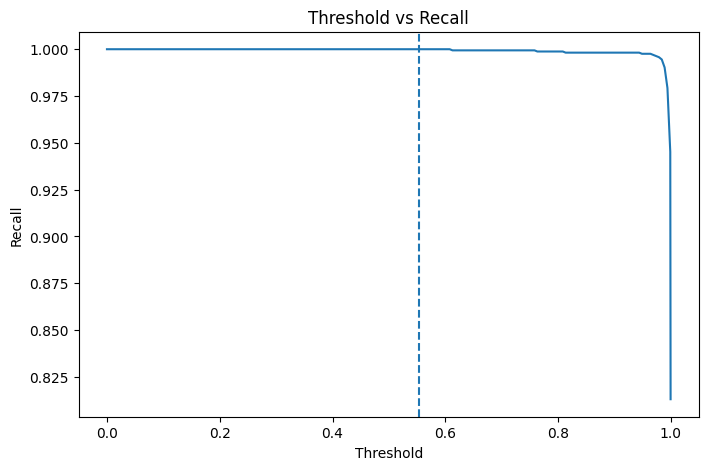

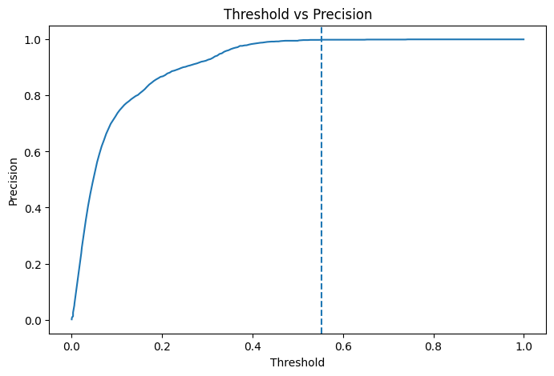

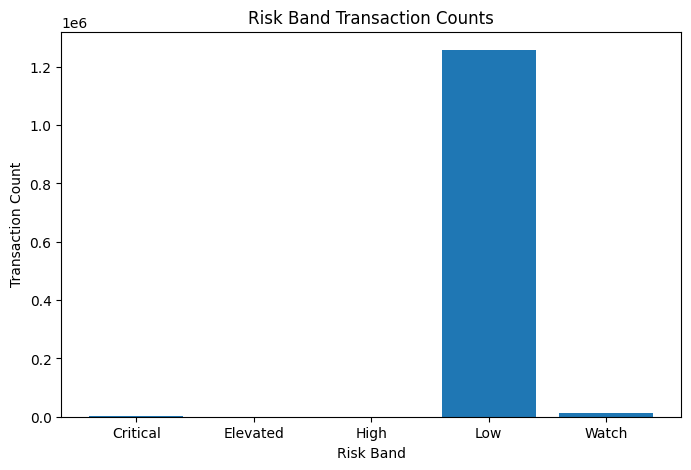

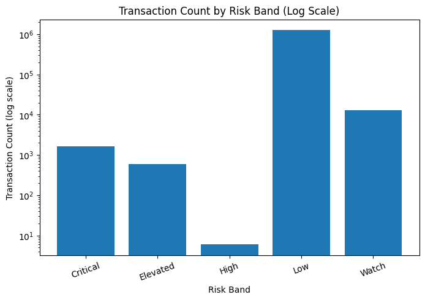

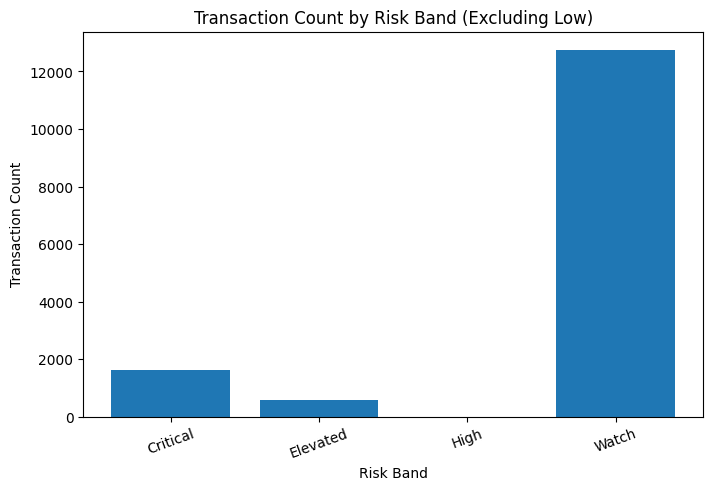

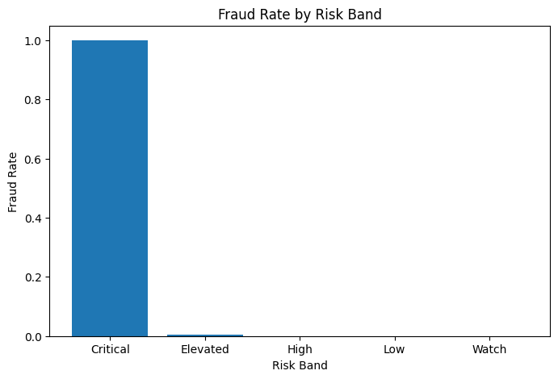

```python
threshold_plot_df = threshold_results_df.sort_values("threshold")

plt.figure(figsize=(8, 5))
plt.plot(threshold_plot_df["threshold"], threshold_plot_df["recall"])
plt.axvline(selected_threshold, linestyle="--")
plt.xlabel("Threshold")
plt.ylabel("Recall")
plt.title("Threshold vs Recall")
plt.show()

plt.figure(figsize=(8, 5))
plt.plot(threshold_plot_df["threshold"], threshold_plot_df["precision"])
plt.axvline(selected_threshold, linestyle="--")
plt.xlabel("Threshold")
plt.ylabel("Precision")
plt.title("Threshold vs Precision")
plt.show()

plt.figure(figsize=(8, 5))
plt.bar(risk_band_summary_df["risk_band"], risk_band_summary_df["transaction_count"])
plt.xlabel("Risk Band")
plt.ylabel("Transaction Count")
plt.title("Risk Band Transaction Counts")
plt.show()

plt.figure(figsize=(8, 5))
plt.bar(risk_band_summary_df["risk_band"], risk_band_summary_df["transaction_count"])
plt.yscale("log")
plt.title("Transaction Count by Risk Band (Log Scale)")
plt.xlabel("Risk Band")
plt.ylabel("Transaction Count (log scale)")
plt.xticks(rotation=20)
plt.show()

risk_band_non_low_df = risk_band_summary_df[
    risk_band_summary_df["risk_band"] != "Low"
].copy()

plt.figure(figsize=(8, 5))
plt.bar(risk_band_non_low_df["risk_band"], risk_band_non_low_df["transaction_count"])
plt.title("Transaction Count by Risk Band (Excluding Low)")
plt.xlabel("Risk Band")
plt.ylabel("Transaction Count")
plt.xticks(rotation=20)
plt.show()

plt.figure(figsize=(8, 5))
plt.bar(risk_band_summary_df["risk_band"], risk_band_summary_df["fraud_rate"])
plt.xlabel("Risk Band")
plt.ylabel("Fraud Rate")
plt.title("Fraud Rate by Risk Band")
plt.show()
```

|  | tn | tp | fp | fn |
| --- | --- | --- | --- | --- |
| 0 | 1270880 | 1639 | 1 | 4 |

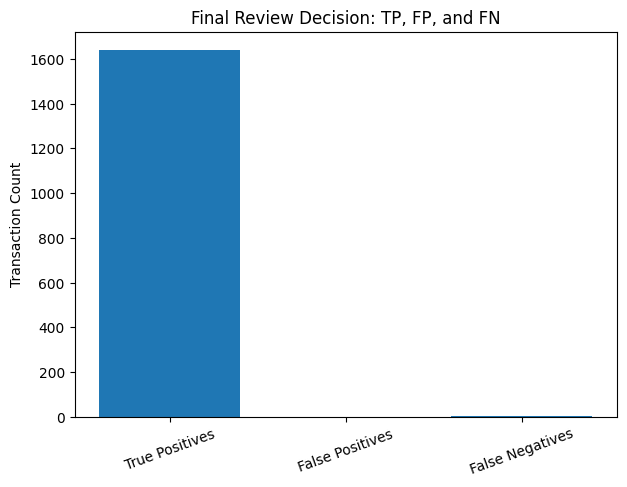

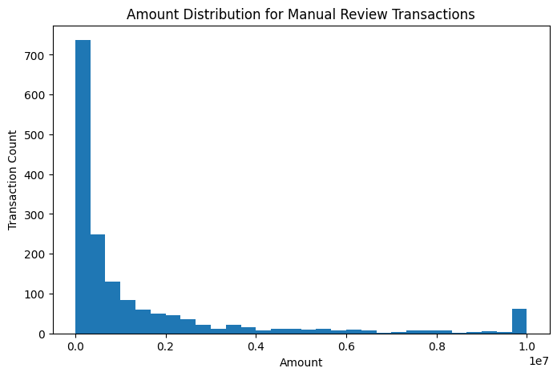

```python
confusion_focus_df = pd.DataFrame(
    {
        "label": ["True Positives", "False Positives", "False Negatives"],
        "count": [
            int(test_final_metrics_df.loc[0, "tp"]),
            int(test_final_metrics_df.loc[0, "fp"]),
            int(test_final_metrics_df.loc[0, "fn"]),
        ],
    }
)

display(test_final_metrics_df[["tn", "tp", "fp", "fn"]])

plt.figure(figsize=(7, 5))
plt.bar(confusion_focus_df["label"], confusion_focus_df["count"])
plt.title("Final Review Decision: TP, FP, and FN")
plt.ylabel("Transaction Count")
plt.xticks(rotation=20)
plt.show()

if "amount" in risk_df.columns:
    reviewed_amounts = risk_df.loc[risk_df["final_review_flag"], "amount"]
    if len(reviewed_amounts) > 0:
        plt.figure(figsize=(8, 5))
        plt.hist(reviewed_amounts, bins=30)
        plt.xlabel("Amount")
        plt.ylabel("Transaction Count")
        plt.title("Amount Distribution for Manual Review Transactions")
        plt.show()
    else:
        print("No transactions were selected for manual review; amount histogram skipped.")
else:
    print("Amount column is unavailable; reviewed amount histogram skipped.")
```

If Autoencoder monitoring fields are present, the chart below compares monitoring flags with final Random Forest review flags. AE monitoring is not a decision rule.

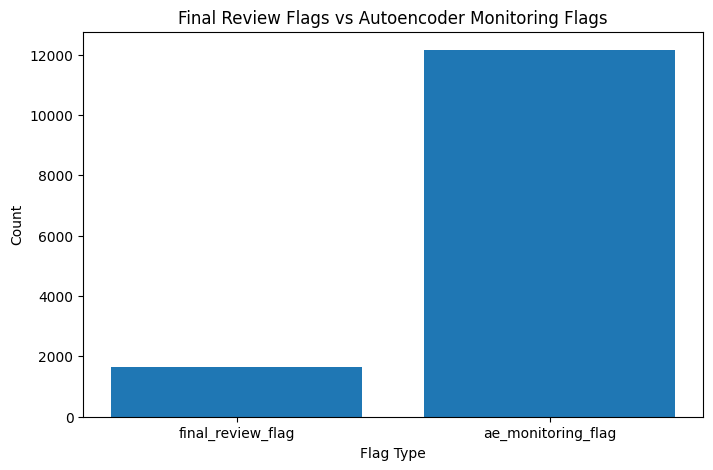

```python
if "ae_monitoring_flag" in risk_df.columns:
    monitoring_counts = pd.Series(
        {
            "final_review_flag": int(risk_df["final_review_flag"].sum()),
            "ae_monitoring_flag": int(risk_df["ae_monitoring_flag"].sum()),
        }
    )
    plt.figure(figsize=(8, 5))
    plt.bar(monitoring_counts.index, monitoring_counts.values)
    plt.xlabel("Flag Type")
    plt.ylabel("Count")
    plt.title("Final Review Flags vs Autoencoder Monitoring Flags")
    plt.show()
else:
    print("Autoencoder monitoring flag is unavailable; optional comparison plot skipped.")
```

## 14. Save Outputs

```python
saved_output_paths = save_risk_scoring_outputs(
    risk_df=risk_df,
    risk_band_summary_df=risk_band_summary_df,
    action_summary_df=action_summary_df,
    metrics_df=test_final_metrics_df,
    threshold_results_df=threshold_results_df,
    threshold_metadata=threshold_metadata,
    dashboard_summary=dashboard_summary,
    output_dir=REPORTS_DIR,
)

for name, path in saved_output_paths.items():
    print(f"{name}: {path.resolve()}")
```

```
risk_df: D:\cs s1 26\基于深度学习的交易欺诈检测与智能风控系统\transaction-fraud-detection-system\reports\final_risk_scoring_test_transactions.csv
risk_band_summary_df: D:\cs s1 26\基于深度学习的交易欺诈检测与智能风控系统\transaction-fraud-detection-system\reports\final_risk_band_summary.csv
action_summary_df: D:\cs s1 26\基于深度学习的交易欺诈检测与智能风控系统\transaction-fraud-detection-system\reports\final_action_summary.csv
metrics_df: D:\cs s1 26\基于深度学习的交易欺诈检测与智能风控系统\transaction-fraud-detection-system\reports\final_risk_scoring_metrics.csv
threshold_results_df: D:\cs s1 26\基于深度学习的交易欺诈检测与智能风控系统\transaction-fraud-detection-system\reports\final_threshold_selection_results.csv
threshold_metadata: D:\cs s1 26\基于深度学习的交易欺诈检测与智能风控系统\transaction-fraud-detection-system\reports\final_decision_threshold.json
dashboard_summary: D:\cs s1 26\基于深度学习的交易欺诈检测与智能风控系统\transaction-fraud-detection-system\reports\dashboard_summary.json
```

## 15. Final Summary

The final system uses Random Forest as the primary decision model. The selected threshold was chosen on validation data only, and test performance is reported once using the selected threshold. The transaction-level output is ready for dashboard or application use.

Autoencoder is retained only as monitoring, not as a hard OR-rule. This remains a post-transaction risk monitoring system because it uses balance-related transaction outcome fields.

The final risk score should be interpreted as a model-based fraud risk score, not necessarily a perfectly calibrated probability.